# Project update

Within the past week we:

- Implemented the calibration algorithm
- Started applying it to some of the miscalibrated posterior predictives
- Researched the calibration metrics
- Formulated some of the properties of the algorithm

# The calibration algorithm

The algorithm has two main steps (from Algorithm 1 listing in the paper):

1. Construct a recalibration dataset $\mathcal{D}$: $$ \mathcal{D} = \left\{\left(\left[H\left(x_t\right)\right]\left(y_t\right), \hat P\left(\left[H\left(x_t\right)\right]\left(y_t\right)\right)\right)\right\}_{t=1}^T $$ where:
   - $T$ is the number of observations
   - $H(x_t)$ is a CDF of the posterior predictive evaluated at $x_t$
   - $H(x_t)(y_t)$ is the predicted quantile of $y_t$
   - $\hat P(p)=\left|\left\{y_t\mid \left[H\left(x_t\right)\right]\left(y_t\right)\lt p, t=1\ldots T\right\}\right|/T$, i.e. the empirical quantile of $y_t$
1. Train a model $R$ (e.g. isotonic regression) on $\mathcal{D}$.

# Setup: The posterior predictive

Say we have the following hypothetical posterior predictive, which is underestimating uncertainty:

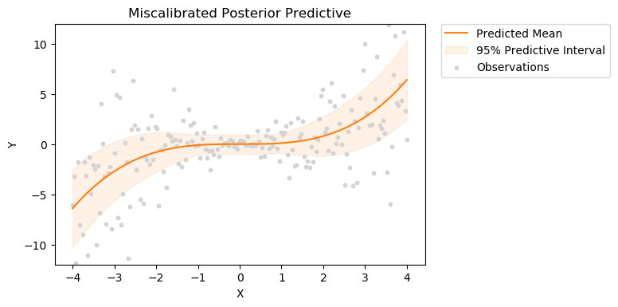

```python
plot_posterior_predictive(ppc, df, title=f"Miscalibrated Posterior Predictive")
```

# Setup: The posterior predictive

For each value of the covariate $X$, the posterior predictive provides us with a conditional distribution $f(Y|X)$:

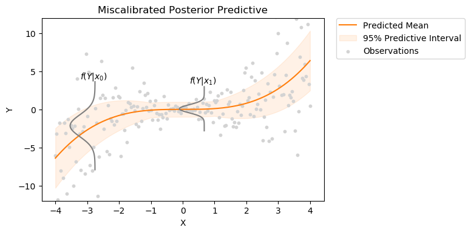

```python
plot_posterior_predictive(ppc, df, title=f"Miscalibrated Posterior Predictive",
                          conditionals=True)
```

# Step 1: Construct a recalibration dataset

The first step of the calibration algorithm is to obtain predictive conditional distributions for each $X$ in the dataset. If no closed-form is available we simulate the posterior predictive based on the samples of the posterior:

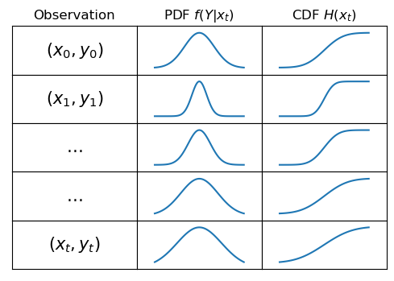

```python
plot_table()
```

Alternative notation: $H(x_t) = F_t$ (a CDF)

# Step 1a: Compute the predicted quantiles

The observed $Y$ for each data point falls somewhere within those conditional distributions:

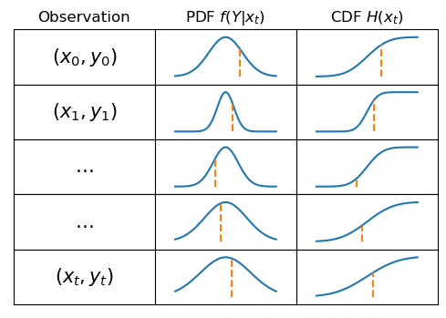

```python
plot_table(mark_y=True)
```

# Step 1a: Compute the predicted quantiles

We evaluate the conditional CDFs at each observed value of the response $Y$ to obtain the predicted quantiles. In the absence of analytical form, we simply count the proportion of samples that are less than $y_t$. This gives us the estimated quantile of $y_t$ at $x_t$ in the posterior predictive distribution:

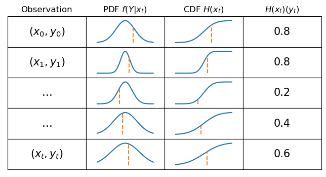

```python
plot_table(mark_y=True, show_quantiles="predicted")
```

# Step 1b: Estimate the empirical quantiles

We next find the empirical quantiles, which are defined as the proportion of observations that have lower quantile values than that of the current observation. This is equivalent to finding the empirical CDF of the predicted quantiles:

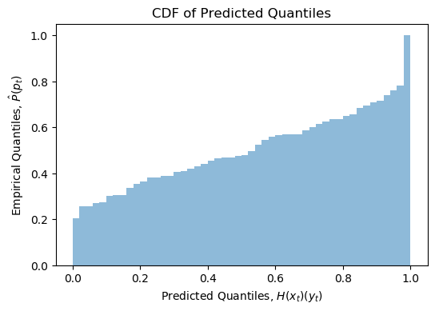

```python
# Estimate the predicted quantiles and plot their CDF
predicted_quantiles = ppc_quantiles(df.y)
plot_ecdf(predicted_quantiles)
```

# Step 1b: Estimate the empirical quantiles

The mapping of predicted quantiles and the empirical quantiles will form a recalibration dataset:

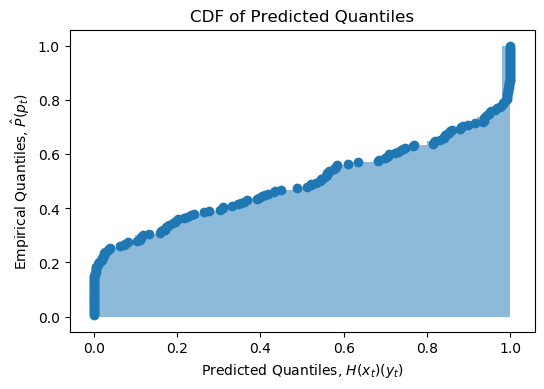

```python
# Compute the empirical quantiles and plot them against predicted quantiles
T = predicted_quantiles.shape[0]
empirical_quantiles = (predicted_quantiles.reshape(1, -1)
                       <= predicted_quantiles.reshape(-1, 1)).sum(axis=1) / T
plot_ecdf(predicted_quantiles)
plt.scatter(predicted_quantiles, empirical_quantiles, color="tab:blue", zorder=2);
```

# Step 1c: Form a recalibration dataset

The mapping is obtained for all observations in the dataset. Note that in this example the first two observations have different conditional distributions, but the same values of the predicted and empirical quantiles. The calibration procedure doesn't distinguish between such cases:

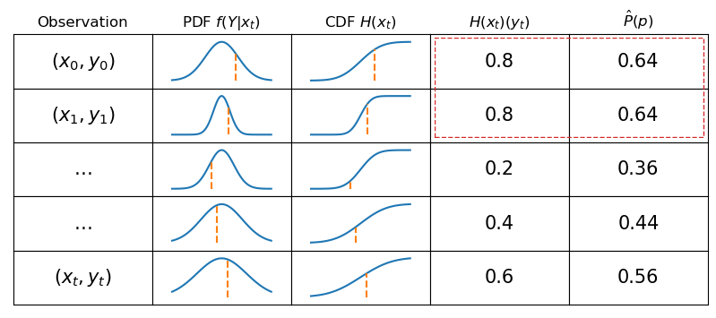

```python
plot_table(mark_y=True, show_quantiles="all")
```

# Step 1c: Form a recalibration dataset

The inverse S-curve of the recalibration dataset in our example is characteristic of a posterior predictive that underestimates uncertainty:

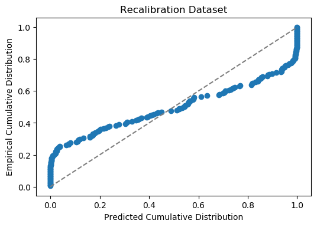

```python
plt.scatter(predicted_quantiles, empirical_quantiles)
plt.plot([0, 1], [0, 1], color="tab:grey", linestyle="--")
plt.xlabel("Predicted Cumulative Distribution")
plt.ylabel("Empirical Cumulative Distribution")
plt.title("Recalibration Dataset");
```

# Step 2: Train a model

We then train a model (e.g. isotonic regression) on the recalibration dataset and use it to output the actual probability of any given quantile or interval:

```python
# Fit isotonic regression
ir = IsotonicRegression(out_of_bounds="clip")
ir.fit(predicted_quantiles, empirical_quantiles)
# Obtain actual calibrated quantiles
calibrated_quantiles = ir.predict([0.025, 0.5, 0.975])
(pd.DataFrame({"Predicted quantiles": [0.025, 0.5, 0.975],
               "Calibrated quantiles": calibrated_quantiles})
 .round(3).style.hide_index())
```

| Predicted quantiles | Calibrated quantiles |
| --- | --- |
| 0.025 | 0.224 |
| 0.5 | 0.477 |
| 0.975 | 0.776 |

Ideally, the model should be fit on a separate calibration set in order to reduce overfitting. Alternatively, multiple models can be trained in a way similar to cross-validation:

- use $K-1$ folds for training
- use 1 fold for calibration
- at prediction time, the output is the average of $K$ models

# Detailed steps

Concretely, for models without closed form posterior predictive CDF, the calibration algorithm is restated as:

1. Generate $N$ samples from the posterior, $\theta = \left\{\theta_n, n=1\ldots N\right\}$.
2. For each observation, $t \in 1\ldots T$
   - Generate $N$ samples of posterior predictive, $s_{t_n}$, from $\theta$ and evaluated at $x_t$
   - Let $p_t$ be the quantile of $y_t$. Estimate the quantile of $y_t$ as $$p_t = \widehat{\left[H(x_t)\right](y_t)} = \left|\left\{s_{t_n}\mid s_{t_n} \le y_t,n=1\ldots N\right\}\right|/N$$
3. For each $t$
   - calculate $\hat P\left(\widehat{\left[H\left(x_t\right)\right]\left(y_t\right)}\right) = \hat P\left(p_t\right)$ as $$\hat P\left(p_t\right) = \left|\left\{p_u\mid p_u\lt p_t, u=1\ldots T\right\}\right|/T $$ That is, find the proportion of observations that have lower quantile values than that of the current observation.
4. Construct $\mathcal{D} = \left\{\left(\widehat{\left[H\left(x_t\right)\right]\left(y_t\right)}, \hat P\left(\widehat{\left[H\left(x_t\right)\right]\left(y_t\right)}\right)\right)\right\}_{t=1}^T$
5. Train calibration transformation using $\mathcal{D}$ via isotonic regression (or other models). Running prediction on the trained model results in a transformation $R$, $[0,1] \to [0,1]$. We can compose the calibrated model as $R\circ H\left(x_t\right)$.
6. To find the calibrated confidence intervals, we need to remap the original upper and lower limits. For example, the upper limit $y_{t\ high}$ is mapped to the calibrated value $y_{t\ high}'$ as: $$y_{t\ high}'=\left[H\left(x_t\right)\right]^{-1}\left(R^{-1}\left\{\left[H\left(x_t\right)\right]\left(y_{t\ high}\right)\right\}\right)$$

# Diagnostics

As a visual diagnostic tool, the authors suggest using a calibration plot that shows the true frequency of points in each quantile or confidence interval compared to the predicted fraction of points in that interval. Well-calibrated models should be close to a diagonal line:

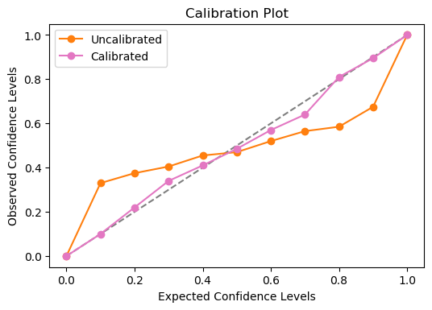

```python
# Perform calibration on a hold-out test dataset
predicted_quantiles_test = ppc_quantiles(df_test.y)
calibration_plot(predicted_quantiles_test, model=ir)
```

# Quantitative metrics

Several alternatives available, each with specific advantages and disadvantages:

**1. Calibration error** $$cal(F_1, y_1, ..., F_N, y_N ) = \sum_{j=1}^m w_j \cdot (p_j − \hat{p}_j)^2$$ Provides a synthetic measure representing the overall *'distance'* of the points on the calibration curve from the $45^\circ$ straight line. The weights ($w_j$) might be used to reduce the importance of intervals containing few observations. Value of $0$ indicates perfect calibration. Sensitive to binning.

**2. Predictive RMSE** $$\sqrt{\frac{1}{N}\sum_{n=1}^{N}||y_n-\mathbb{E}_{q(W)}[f(x_n,W)]||_{2}^{2}}$$
Measures the model *fit* to the observed data by normalizing the difference between observations and the mean of the posterior predictive. Minimizing RMSE does not guarantee calibration of the model.

# Quantitative metrics cont.

**3. Mean prediction interval width** $$\frac{1}{N}\sum_{n=1}^{N}\hat{y}_{n}^{high} - \hat{y}_{n}^{low},$$
where $\hat{y}_{n}^{high}$ and $\hat{y}_{n}^{low}$ are - respectively - the 97.5 and 2.5 percentiles of the predicted outputs for $x_n$. Average difference between the the upper and lower bounds of predictive intervals evaluated for all the observations (different significance values might be used to define the predictive intervals). By itself provides information on the precision of the prediction (*confidence* with which a prediction is made) rather than calibration or miscalibration of the model. However may be used in conjunction with prediction interval coverage probability.

**4. Prediction interval coverage probability** $$\frac{1}{N}\sum_{n=1}^{N}\mathbb{1}_{y_n\leq\hat{y}_{n}^{high}} \cdot \mathbb{1}_{y_n\geq\hat{y}_{n}^{low}} $$
Calculates the share of observations covered by 95% (or any other, selected) predictive intervals. Alignment of the PICP with the probability mass assigned to the predictive interval generating it may misleadingly point to proper calibration if true noise distribution belongs to a different family than the posterior predictive. Requires a large sample of observations.

# Properties of the algorithm (to be tested)

- **Sufficient data:** The procedure requires sufficient i.i.d. data to perform the recalibration. In its absence, point estimates like the median or any other quantile may become worse.
- **Marginal probabilities:** Predicted quantiles are mapped to empirical quantiles uniformly over the entire input space, irrespective of the value of $X$. In other words, quantile-based calibration is based on a marginal probability, not a conditional probability.
- **Calibration on average:** The algorithm does not ensure calibration of a particular prediction, and only aims for the quantile to be calibrated on average over all predictions
- **Arbitrary mappings:** Can arbitrarily change uncertainties to achieve the calibration objective since isotonic regression is always able to find a perfect fit
- **Uninformative calibration:** Does not distinguish between informative and uninformative (random) uncertainties. Any posterior predictive, even a completely wrong one, can be perfectly calibrated (up to a sampling error) according to the quantile definition of calibration. This may make the estimates meaningless for further analysis.

# Example: Bayesian polynomial regression

True function: $$ y_i = 0.1x_i^3 + \varepsilon, \text{ where } \varepsilon \sim \mathcal{N}(0, 1) $$

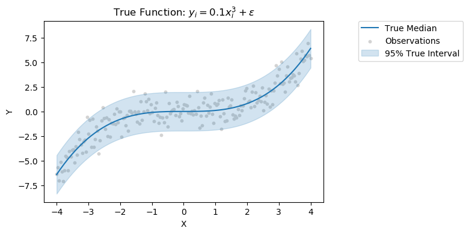

```python
plot_distributions(df, true_func = polynomial,
                   title=r"True Function: $y_i = 0.1x_i^3 + \varepsilon$")
```

# Example: Bayesian polynomial regression

Bayesian polynomial regression model (with unrealistically low noise in the likelihood):

$$ a, b, c, d \sim \mathcal{N}(0, 1) \\ f(X) = a X^3 + b X^2 + c X + d \\ Y_{observed} \sim \mathcal{N}(f(X), 0.5) $$

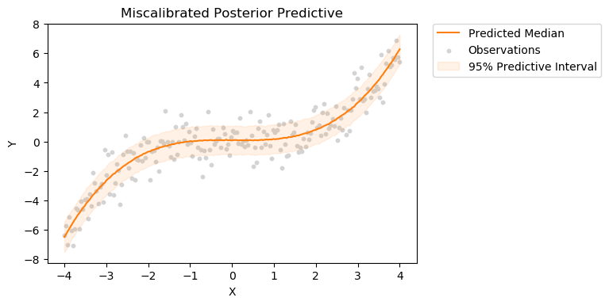

```python
plot_distributions(df, posterior_predictive,
                   title="Miscalibrated Posterior Predictive")
```

# Results of calibration

```python
# Remove the if statement below when all of the procedures are implemented
INVERTER = False

from statsmodels.distributions.empirical_distribution import monotone_fn_inverter

def calibrate_model_pred(R, get_post_pred, posterior_samples, x, y):
    posterior_predictive_samples = get_post_pred(posterior_samples, x)
    emp_cdf = lambda uncal_y: calculate_percentiles(posterior_predictive_samples,
                                                    uncal_y)
    y_p = emp_cdf(y)
    inv_R = monotone_fn_inverter(cal_transform, y_p)
    inv_H = monotone_fn_inverter(emp_cdf, inv_R)

    return inv_H

if INVERTER:
    # get_post_pred is a function that returns the posterior_predictive given x and posterior
    # trace_from_pymc3 is the set of posterior samples
    calibrate_mode_pred(ir.predict, get_post_pred, trace_from_pymc3, x, y)
```

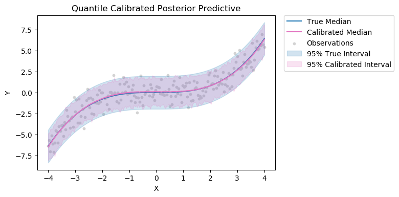

```python
# Build a recalibration dataset using out-of-sample data
predicted, empirical = make_cal_dataset(df_cal.y, posterior_predictive_cal)
# Fit the recalibration dataset in reverse: from empirical to predicted
ir = IsotonicRegression(out_of_bounds="clip")
ir.fit(empirical, predicted)
calibrated_quantiles = ir.predict([0.025, 0.5, 0.975])
plot_distributions(df, posterior_predictive,
                   plot_uncalibrated=False, true_func=polynomial,
                   calibrated_quantiles=calibrated_quantiles,
                   title="Quantile Calibrated Posterior Predictive")
```

# Open questions

- Would like to confirm validity of the implementation approach, since sampling is not explicitly mentioned in the paper.
- What about the variance introduced by estimating $\left[H\left(x_t\right)\right]\left(y_t\right)$ – how will this affect the calibration? Should we take this into account? Perhaps we can:
  - compare calibration for conjugate models without sampling (in "Detailed Step" 2) with calibration using sampling;
  - repeatedly calibrate the same model using sampling to study calibration variance.
- For non-Bayesian models (MLE), can this calibration via sampling method be applied to bootstraps?
- If the idea above is valid, would it be a viable alternative to arbitrarily constructing a CDF (proposed in section 3.4 of the paper)?
- Since the calibration model (step 5) is trained on a single dataset for all values of $X$, we expect the transformation to be applied uniformly w.r.t. $X$. Is it reasonable to expect intervals in certain regions to get overly compressed/expanded after calibration?
- What is the effect on the expected log likelihood of the calibrated model? Something worth investigating?

# Next steps

- Further research on miscalibration arising from:
  - heteroscedastic noise,
  - non-Gaussian noise,
  - wrong likelihood function,
  - and different choices of data-generating functions
- Application of the calibration algorithm and subsequent analysis of its effects on the posterior predictive, as well as on point estimates (median, mean, MAP)
- Quantitative assessment of calibration results in terms of selected metrics